# Mouse_phylo_analysis

2024-06-24

## Load in the data for one individual

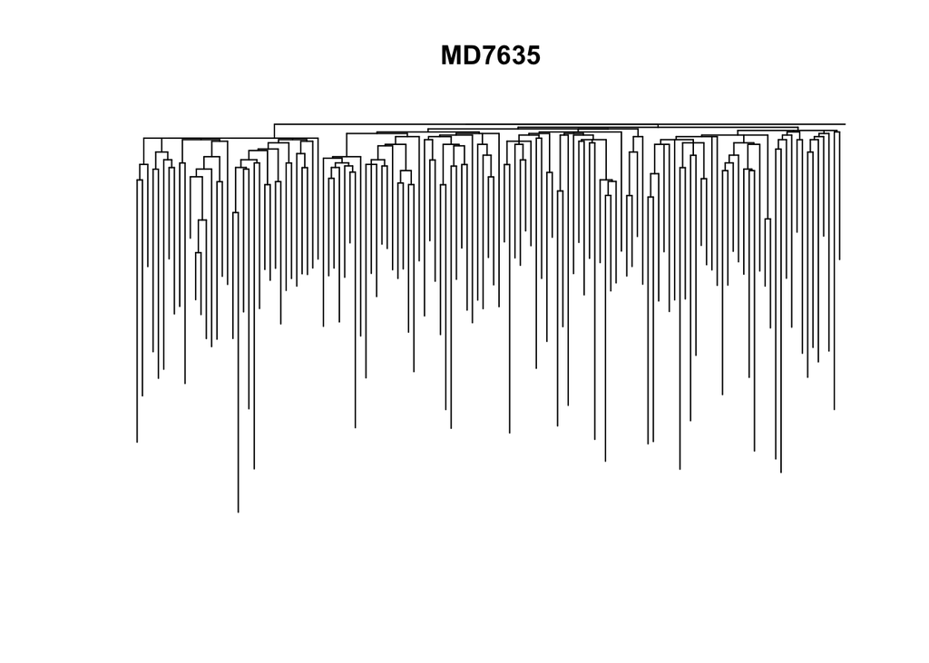

```r
knitr::opts_knit$set(root.dir = my_working_dir,echo = TRUE)
sample_ID="MD7635"
load(paste0(my_working_dir,"annotated_muts/annotated_mut_set_",sample_ID,"_postMS_reduced_a_j_vaf_post_mix_post_dup"))
tree=read.tree(paste0(my_working_dir,"tree_files/tree_",sample_ID,"_postMS_reduced_a_j_vaf_post_mix_post_dup.tree"))
details<-filtered_muts$COMB_mats.tree.build$mat
plot.phylo(tree,show.tip.label=F,direction="downwards",main=sample_ID)
```

```r
sample_level_metadata<-readxl::read_excel(paste0(my_working_dir,"sample_metadata/CAMPUOY000001_REUPLOAD_20231116_4xplates_York_Lily_CASM_STS_Sample_MANIFEST_Rec20231206_WithCGPIDs20231219.xlsx"))
```

```r
cell_type_colours=c("#219EBC","#023047","#FFB703", "#FB8500")
names(cell_type_colours)<-unique(sample_level_metadata$TISSUE_PHENOTYPE)

tree=plot_tree(tree = tree,cex.label=0,title = sample_ID)
```

```
## scale= 10
```

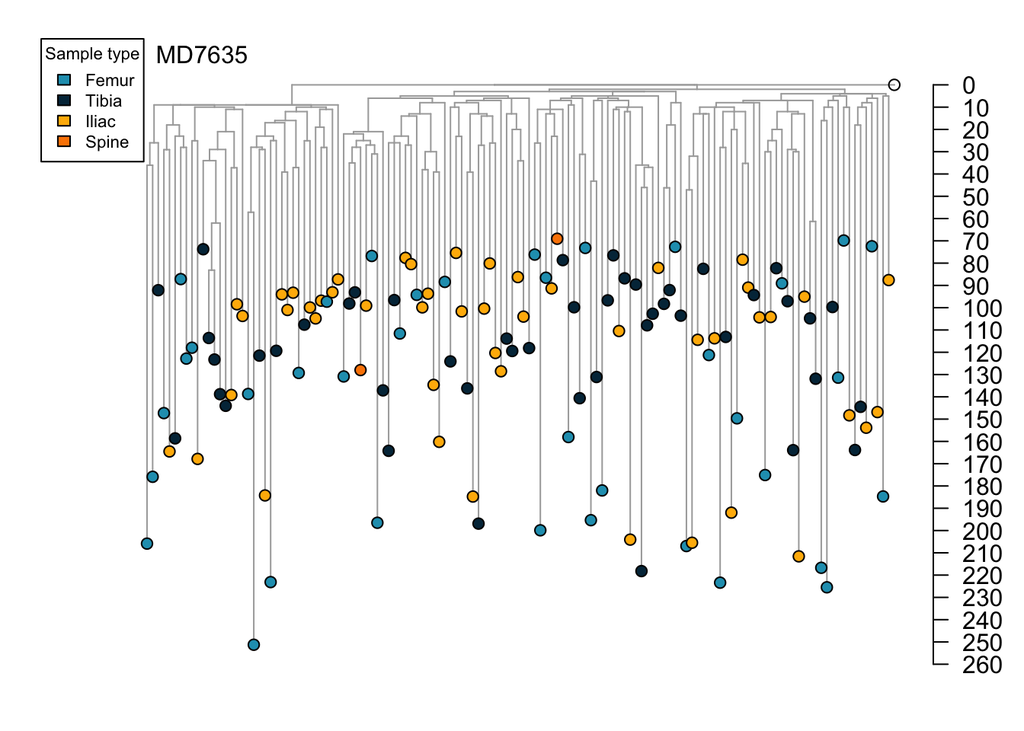

```r
temp=sapply(tree$tip.label,function(sample_ID) plot_category_tip_point(sample_ID = sample_ID,
                                                                  tree=tree, cat_df=sample_level_metadata%>%mutate("sample"=INTERNAL_CASM_SAMPLE_NAME),
                                                                  cols = cell_type_colours,
                                                                  cat_name="TISSUE_PHENOTYPE"))

#Plot the legend
legend("topleft", inset=c(.01,.01), title="Sample type",
       names(cell_type_colours), fill=cell_type_colours, horiz=F, cex=0.7)
```

```r
sum(filtered_muts$COMB_mats.tree.build$mat$node%in%1:length(tree$tip.label))
```

```
## [1] 12648
```

```r
sum(!filtered_muts$COMB_mats.tree.build$mat$node%in%1:length(tree$tip.label))
```

```
## [1] 1144
```

## Plot trees with tissue source info

In this plot, branches are coloured by the specific tissue colour if all the descendants are from the same tissue. If descendants come from different tissues, the colour is black.

```r
#Can choose the
plot_sharing_multiple=function(tree,details,matrices,node,cat_df,cat_name="cat",sharing_cols=c("dark green","red","orange","brown","green"),...){
  library(dplyr)
  categories=cat_df%>%filter(sample%in%tree$tip.label)%>%pull(cat_name)%>%unique()
  if(length(categories)>length(sharing_cols)) {stop("Not enough colours supplied for number of categories")}
  info=get_edge_info(tree,details,node=node)
  sample_categories=cat_df%>%filter(sample%in%info$samples)%>%pull(cat_name)
  if(length(unique(sample_categories))>1) {
    sharing_info <- "shared"
  } else {
    sharing_info <- unique(sample_categories)
  }
  sharing_cols=sharing_cols[1:length(categories)]

  #Add black as the first "shared" category colour
  if(all(categories%in%names(sharing_cols))) {
    sharing_cols<-sharing_cols[categories]
    sharing_cols<-c("black",sharing_cols)
    names(sharing_cols)[1]="shared"
  } else {
    sharing_cols<-c("black",sharing_cols)
    names(sharing_cols)=c("shared",categories)
  }

  if(length(tree$edge.length[tree$edge[,2]==node])>0){
    arrows(y0=info$yb,y1=info$yt,x0=info$x,x1=info$x,length=0,col=sharing_cols[sharing_info],lend=1,...)
  }
}

tree=plot_tree(tree,cex.label=0,plot_axis = T,b_do_not_plot = T)

tree.ultra=make.ultrametric.tree(tree)
tree.ultra$coords<-NULL
tree.ultra$edge.length[is.infinite(tree.ultra$edge.length)]<-0
tree.ultra$edge.length<-tree.ultra$edge.length*mean(get_mut_burden(tree))
tree.ultra=plot_tree(tree.ultra,cex.label=0,plot_axis = T,title = sample_ID)
```

```
## scale= 10
```

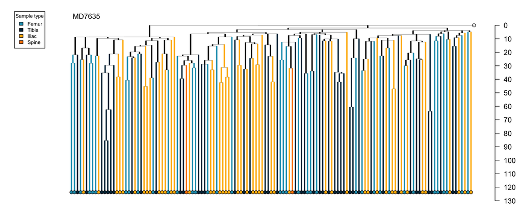

```r
#cell_type_colours=c("gray75","#B3CDE3","#CCEBC5", "#9970AB")
cell_type_colours=c("#219EBC","#023047","#FFB703", "#FB8500")
names(cell_type_colours)<-unique(sample_level_metadata$TISSUE_PHENOTYPE)
cell_type_colours<-cell_type_colours[which(names(cell_type_colours)%in%(sample_level_metadata%>%dplyr::filter(INTERNAL_CASM_SAMPLE_NAME%in%tree$tip.label)%>%pull(TISSUE_PHENOTYPE)))]

#Apply the 'plot_sharing_multiple' function to colour the branches
temp=add_annotation(tree=tree.ultra,
               annot_function=plot_sharing_multiple,
               cat_df=sample_level_metadata%>%mutate("sample"=INTERNAL_CASM_SAMPLE_NAME),
               cat_name="TISSUE_PHENOTYPE",
               lwd=3,
               sharing_cols=cell_type_colours)

#Apply the 'plot_category_tip_point' function to create coloured tips according to the tissue
temp=sapply(tree.ultra$tip.label,function(sample_ID) plot_category_tip_point(sample_ID = sample_ID,
                                                                  tree=tree.ultra, cat_df=sample_level_metadata%>%mutate("sample"=INTERNAL_CASM_SAMPLE_NAME),
                                                                  cat_name="TISSUE_PHENOTYPE",
                                                                  cols=cell_type_colours,
                                                                  cex=1))

#Plot the legend
legend("topleft", inset=c(.01,.01), title="Sample type",
       names(cell_type_colours), fill=cell_type_colours, horiz=F, cex=0.7)
```

## AMOVA (Analysis of molecular variance)

This is a statistical measure of whether samples are more clustered by cell source than you would expect by chance. This is done on the ultrametric tree.

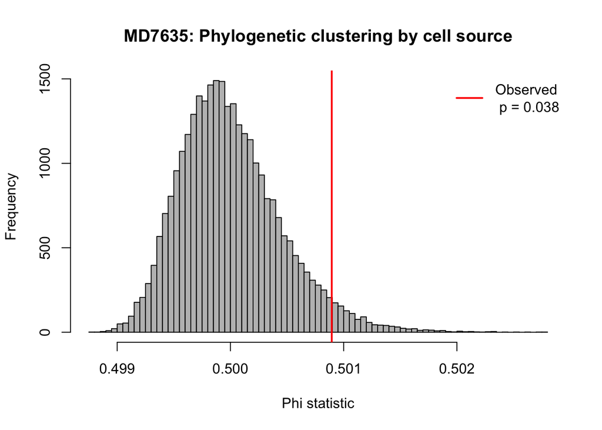

```r
cellkey<-sample_level_metadata%>%
  dplyr::mutate("Sample"=INTERNAL_CASM_SAMPLE_NAME)%>%
  dplyr::filter(Sample%in%tree$tip.label)%>%
  dplyr::select(Sample,TISSUE_PHENOTYPE)%>%
  dplyr::rename("Cell_type"=TISSUE_PHENOTYPE)

distmat <- cophenetic(drop.tip(tree.ultra,"Ancestral"))

amovapval.fn(distmat = distmat,
             groupnames = unique(cellkey$Cell_type),
             cell_key = cellkey,
             iterations = 30000,
             plottitle = paste0(sample_ID,": Phylogenetic clustering by cell source"))
```

## Plot the mutational signatures

Shared mutations are highly confident to be acquired in vivo as they are present in two independent sorted colonies. Private mutations may - in theory - be a combination of in vivo acquired and in vitro acquired mutations. Looking at the mutational signatures of the two may give a clue as to any differences.

Differences may be due to:

1. in vitro-acquired mutations that have a different mutational signature
2. differences in in vivo mutational process between mutations acquired early in embryogenesis (these are more likely to be shared) and those acquired later (these are likely to be private)

For reasons explained later, in this case, the differences are likely due to in vitro-acquired mutations in this case.

```r
par(mfrow=c(2,1))
plot_96profile(df = details%>%mutate(sampleID=sample_ID)%>%filter(node%in%1:length(tree$tip.label)),colnames = c("sampleID","Chrom","Pos","Ref","Alt"),genomeFile = gfile,title="Private mutations")
plot_96profile(df = details%>%mutate(sampleID=sample_ID)%>%filter(!node%in%1:length(tree$tip.label)),colnames = c("sampleID","Chrom","Pos","Ref","Alt"),genomeFile = gfile, title="Shared mutations")
```

[output not shown]

## Look at the VAF density plots of the private mutations in a few individual samples

This chooses the first 16 tips of the tree and looks at the VAF density plots of the private mutations

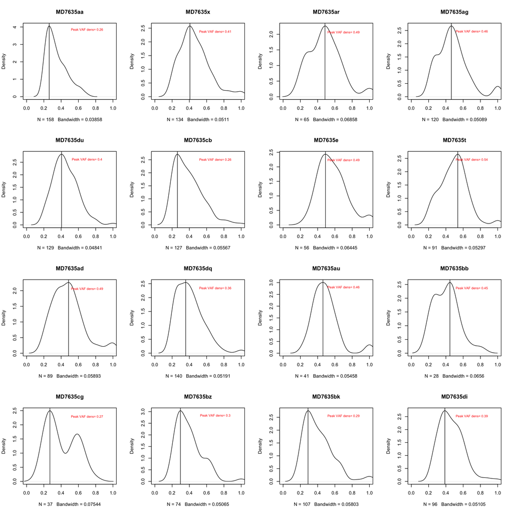

## Review the VAF histograms of all private mutations from all samples

What is the overall story here? What proportion of private mutations are in fact subclonal or artefactual?

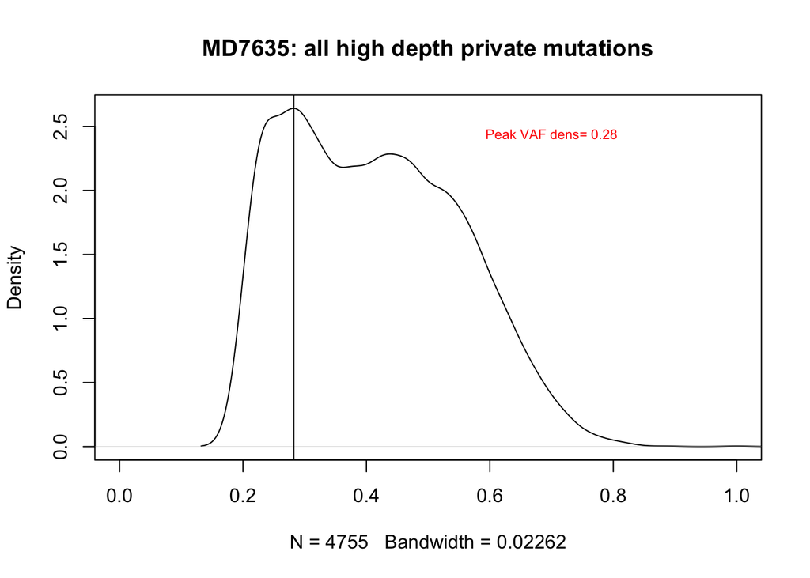

```r
COMB_mats=filtered_muts$COMB_mats.tree.build

#Concatentate all variant read counts (of private mutations) into single vector
all_NV<-lapply(head(tree$tip.label,-1),function(sample) {
  node <- which(tree$tip.label==sample)
  sample_muts <- COMB_mats$mat$mut_ref[COMB_mats$mat$node %in% node]
  COMB_mats$NR[COMB_mats$NR == 0] <- 1
  return(COMB_mats$NV[sample_muts,sample])
})%>%unlist()

#Concatentate all depth counts into single vector
all_NR<-lapply(head(tree$tip.label,-1),function(Sample) {
  node <- which(tree$tip.label==Sample)
  sample_muts <- COMB_mats$mat$mut_ref[COMB_mats$mat$node %in% node]
  COMB_mats$NR[COMB_mats$NR == 0] <- 1
  sample_NR=COMB_mats$NR[sample_muts,Sample]
  names(sample_NR)<-sample_muts
  return(sample_NR)
})%>%unlist()

#Plot as a density map
dens <- density(all_NV[all_NR>20]/all_NR[all_NR>20])
plot(dens,xlim = c(0,1),main=paste0(sample_ID,": all high depth private mutations"))
abline(v = dens$x[which.max(dens$y)])
text(0.7, max(dens$y) - 0.2, paste("Peak VAF dens=",round(dens$x[which.max(dens$y)], digits = 2)),col="red",cex = 0.7)
```

### Now apply a binomial mixture model to the higher depth mutations

This separates the counts into those that are likely clonal (i.e. from a peak with VAF ~0.5) and those that are likely sub-clonal (i.e. those with a peak VAF ~0.25 -0.33).

This is done only with the higher depth mutations where the underlying true clonal fractions can be inferred with greater confidence

```r
depth_cutoff=20
total<-sum(all_NR>depth_cutoff)
print(total)
```

```
## [1] 4755
```

```r
set.seed(15)
model.out=binom_mix(x=all_NV[all_NR>depth_cutoff],size=all_NR[all_NR>depth_cutoff],nrange=1:4)

clonal_clusters=which.min(abs(model.out$p-0.5))

if(any(model.out$p>model.out$p[clonal_clusters])) {
    clonal_clusters<-c(clonal_clusters,which(model.out$p>model.out$p[clonal_clusters]))
}

if(any(model.out$p<model.out$p[clonal_clusters[1]])) {
  subclonal_clusters=which(model.out$p<model.out$p[clonal_clusters[1]])
}

clonal_mut_refs=names(all_NR)[all_NR>depth_cutoff][which(model.out$Which_cluster%in%clonal_clusters)]
subclonal_mut_refs=names(all_NR)[all_NR>depth_cutoff][which(model.out$Which_cluster%in%subclonal_clusters)]

print(paste(length(clonal_mut_refs),"mutations of",total,"are likely clonal"))
```

```
## [1] "1940 mutations of 4755 are likely clonal"
```

```r
print(paste(length(subclonal_mut_refs),"mutations of",total,"are likely sub-clonal"))
```

```
## [1] "2815 mutations of 4755 are likely sub-clonal"
```

```r
#Given this what are the likely number of true muts amongst all mutations
nclonal<-round(length(all_NR) * length(clonal_mut_refs)/total)
nsubclonal<-round(length(all_NR) * length(subclonal_mut_refs)/total)

plot_signatures=F
if(plot_signatures) {
  plot_96profile_mutref(clonal_mut_refs,genomeFile = gfile,title="Clonal mutations")
  plot_96profile_mutref(subclonal_mut_refs,genomeFile = gfile,title="Probable sub-clonal mutations")
}
```

### Try applying the binomial mixture model to private mutations from each sample individually

The challenge here is that there may not be enough mutations in many cases. But lets see how it performs.

```r
all_individual_binom_mix<-lapply(head(tree$tip.label,-1),function(sample) {
  node <- which(tree$tip.label==sample)
  sample_muts <- COMB_mats$mat$mut_ref[COMB_mats$mat$node %in% node]
  COMB_mats$NR[COMB_mats$NR == 0] <- 1
  sample_NV=COMB_mats$NV[sample_muts,sample]
  sample_NR=COMB_mats$NR[sample_muts,sample]

  plot=F
  if(plot) {
    dens <- density(sample_NV/sample_NR)
    plot(dens,xlim = c(0,1),main=paste0(sample,": all private mutations"))
    abline(v = dens$x[which.max(dens$y)])
    text(0.7, max(dens$y) - 0.2, paste("Peak VAF dens=",round(dens$x[which.max(dens$y)], digits = 2)),col="red",cex = 0.7)
  }


  model.out=binom_mix(x=sample_NV,size=sample_NR,nrange=1:4)

  clonal_clusters=which.min(abs(model.out$p-0.5))

  if(any(model.out$p>model.out$p[clonal_clusters])) {
    clonal_clusters<-c(clonal_clusters,which(model.out$p>model.out$p[clonal_clusters]))
  }

  if(clonal_clusters[1]==which.min(model.out$p)) {
    subclonal_cluster<-NULL
    subclonal_mut_refs<-NULL
  } else {
    subclonal_cluster=which.min(model.out$p)
    subclonal_mut_refs=sample_muts[which(model.out$Which_cluster==subclonal_cluster)]
  }

  clonal_mut_refs=sample_muts[which(model.out$Which_cluster%in%clonal_clusters)]
  return(list(clonal_mut_refs=clonal_mut_refs,
              subclonal_mut_refs=subclonal_mut_refs))

})

#This classifies the majority as likely clonal - but not sure I trust this
all_clonal_muts<-unlist(lapply(all_individual_binom_mix,function(list) {return(list$clonal_mut_refs)}))
all_sub_clonal_muts<-unlist(lapply(all_individual_binom_mix,function(list) {return(list$subclonal_mut_refs)}))

#Alternatively use a Bayesian approach to classify individual mutations
#1. Take the clonal vs subclonal proportions from the high coverage muts as the prior likelihoods
#.  i.e. clonal proportion = 1545/3893

clonal_prob_prior=length(clonal_mut_refs)/total
subclonal_prob_prior=length(subclonal_mut_refs)/total

decisions_df<-lapply(1:length(all_NR),function(i) {
  clonal_prob=clonal_prob_prior*dbinom(x=all_NV[i],size=all_NR[i],prob=0.5) #The binomial prob for a clonal mutation
  subclonal_prob=subclonal_prob_prior*dbinom(x=all_NV[i],size=all_NR[i],prob=0.33) #The approximate prob for the subclonal mutations is 0.33 according to the binomial mixture model

  clonal_prob_norm=clonal_prob/(clonal_prob+subclonal_prob)
  sub_prob_norm=subclonal_prob/(clonal_prob+subclonal_prob)
  data.frame(mut_ref=names(all_NR)[i],
             clonal_prob=clonal_prob_norm,
             subclonal_prob=sub_prob_norm,
             decision=ifelse(clonal_prob>subclonal_prob,"clonal","sub-clonal"))
})%>%dplyr::bind_rows()

decisions_df$sample<-sapply(decisions_df$mut_ref,function(mut) {
  mut_node<-COMB_mats$mat%>%filter(mut_ref==mut)%>%pull(node)
  return(tree$tip.label[mut_node])
})

table(decisions_df$decision)
```

```
##
##     clonal sub-clonal
##       5676       6972
```

### Using these corrected mutation burdens

```r
correction_factor<-sapply(head(tree$tip.label,-1),function(sampleID) {
  decisions_df%>%filter(sample==sampleID)%>%
    summarise(prop_clonal=sum(decision=="clonal")/nrow(.))%>%unlist()
})
names(correction_factor)<-head(tree$tip.label,-1)
tree.corrected<-tree
tree.corrected$edge.length<-sapply(tree$edge[,2],function(node) {
  original_edge_length<-tree$edge.length[tree$edge[,2]==node]
  if(!node %in% 1:length(tree$tip.label)) {
    return(original_edge_length)
  } else {
    sampleID<-tree$tip.label[node]
    if(sampleID=="Ancestral") {
      return(0)
    } else {
      new_edge_length<-original_edge_length*correction_factor[sampleID]
      return(new_edge_length)
    }
  }
})

#Plot the tree with the corrected burdens
tree.corrected$coords<-NULL
tree.corrected=plot_tree(tree = tree.corrected,cex.label=0,title = sample_ID)
```

```
## scale= 10
```

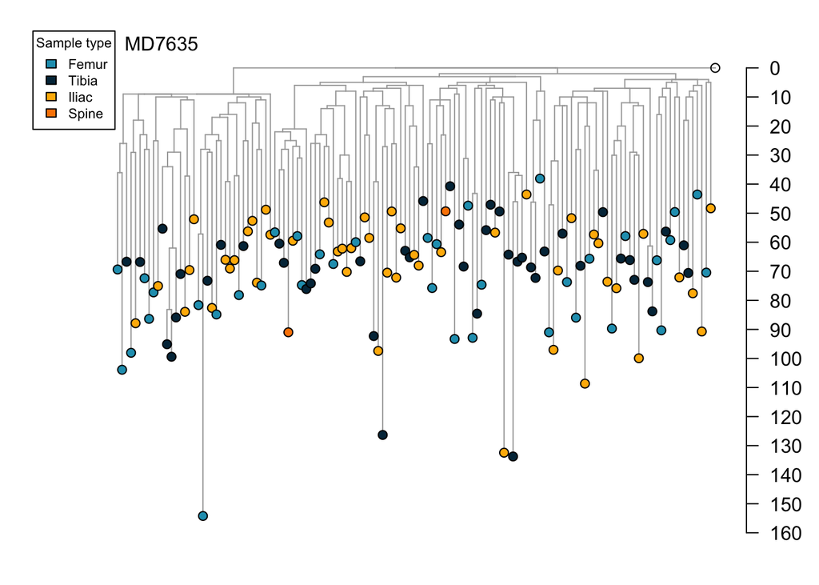

```r
temp=sapply(tree.corrected$tip.label,function(sample_ID) plot_category_tip_point(sample_ID = sample_ID,
                                                                  tree=tree.corrected, cat_df=sample_level_metadata%>%mutate("sample"=INTERNAL_CASM_SAMPLE_NAME),
                                                                  cols = cell_type_colours,
                                                                  cat_name="TISSUE_PHENOTYPE"))

#Plot the legend
legend("topleft", inset=c(.01,.01), title="Sample type",
       names(cell_type_colours), fill=cell_type_colours, horiz=F, cex=0.7)
```

```r
## From this, look at the mutation burdens
#Create a dataframe including burden, sample name and tissue type
mut_burden_df<-data.frame(sampleID=tree.corrected$tip.label,mut_burden=get_mut_burden(tree.corrected))%>%
  filter(!sampleID=="Ancestral")%>%
  left_join(sample_level_metadata,by=c("sampleID"="INTERNAL_CASM_SAMPLE_NAME"))


#Overall mean mutation burden
print(mean(mut_burden_df$mut_burden))
```

```
## [1] 70.44279
```

```r
#Summarise mean burdens per tissue of origin
mut_burden_df%>%
  group_by(TISSUE_PHENOTYPE)%>%
  summarise(n_samples=n(),mean_burden=mean(mut_burden),median_burden=median(mut_burden))%>%
  print()
```

```
## # A tibble: 4 × 4
##   TISSUE_PHENOTYPE n_samples mean_burden median_burden
##   <chr>                <int>       <dbl>         <dbl>
## 1 Femur                   37        74.2          73.7
## 2 Iliac                   48        68.4          65.2
## 3 Spine                    2        70.2          70.2
## 4 Tibia                   46        69.6          66.7
```

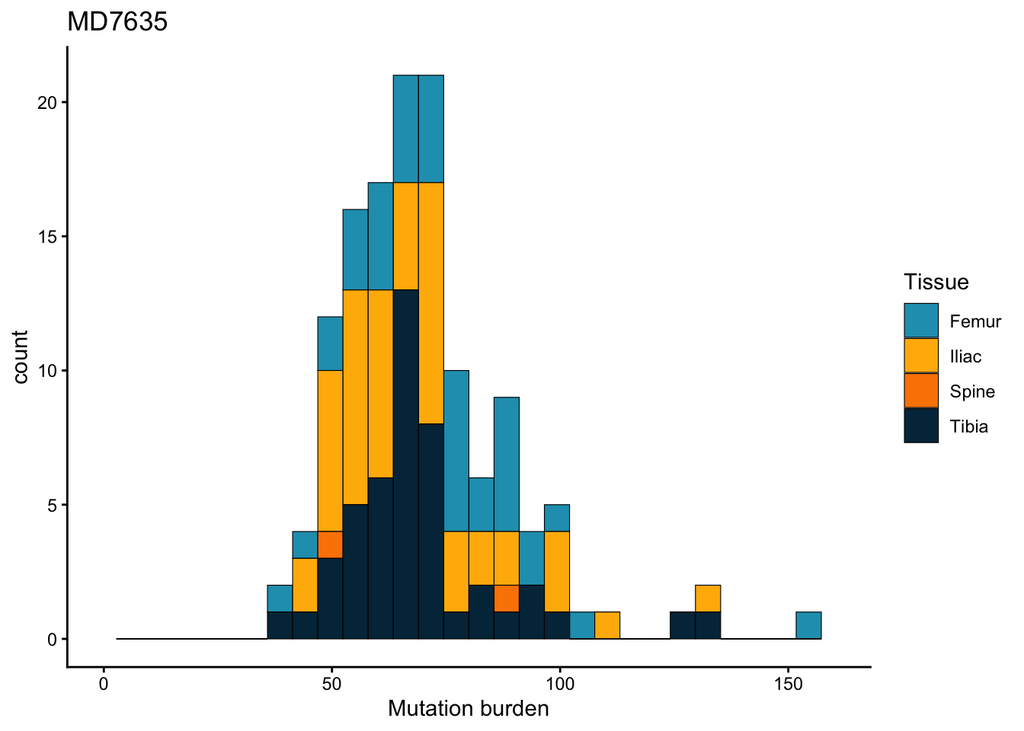

```r
#Plot a histogram of the burdens, separated by tissue type
mut_burden_df%>%
  ggplot(aes(x=mut_burden,fill=TISSUE_PHENOTYPE))+
  geom_histogram(col="black",linewidth=0.2)+
  scale_fill_manual(values=cell_type_colours)+
  theme_classic()+
  scale_x_continuous(limits=c(0,160))+
  labs(fill="Tissue",x="Mutation burden",title = sample_ID)
```

### Make a new ultrametric tree with the corrected mutation burdens

```r
tree.corrected.ultra=make.ultrametric.tree(tree.corrected)
tree.corrected.ultra$coords<-NULL
tree.corrected.ultra$edge.length[is.infinite(tree.corrected.ultra$edge.length)]<-0
tree.corrected.ultra$edge.length<-tree.corrected.ultra$edge.length*mean(get_mut_burden(tree.corrected))
tree.corrected.ultra=plot_tree(tree.corrected.ultra,cex.label=0,plot_axis = T,title = sample_ID)
```

```
## scale= 10
```

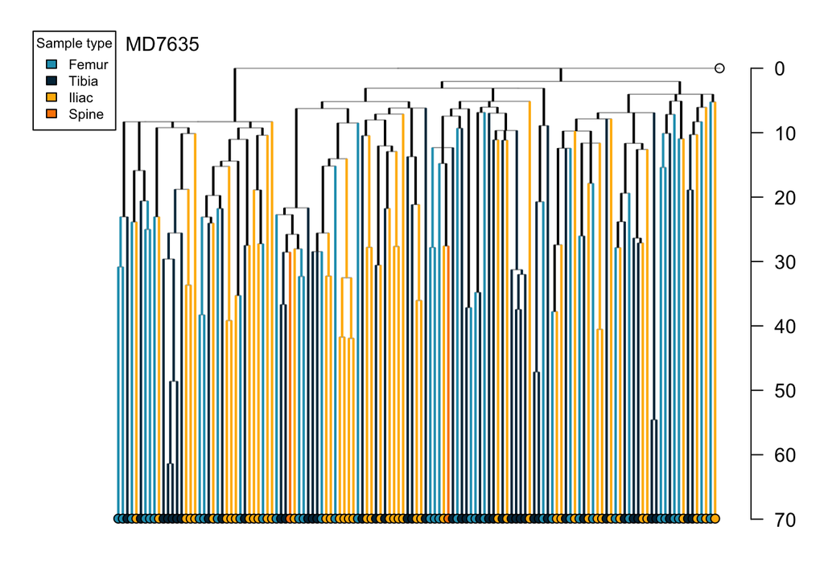

```r
#Apply the 'plot_sharing_multiple' function to colour the branches
temp=add_annotation(tree=tree.corrected.ultra,
               annot_function=plot_sharing_multiple,
               cat_df=sample_level_metadata%>%mutate("sample"=INTERNAL_CASM_SAMPLE_NAME),
               cat_name="TISSUE_PHENOTYPE",
               lwd=2,
               sharing_cols=cell_type_colours)

#Apply the 'plot_category_tip_point' function to create coloured tips according to the tissue
temp=sapply(tree.corrected.ultra$tip.label,function(sample_ID) plot_category_tip_point(sample_ID = sample_ID,
                                                                  tree=tree.corrected.ultra, cat_df=sample_level_metadata%>%mutate("sample"=INTERNAL_CASM_SAMPLE_NAME),
                                                                  cat_name="TISSUE_PHENOTYPE",
                                                                  cols=cell_type_colours,
                                                                  cex=1))

#Plot the legend
legend("topleft", inset=c(.01,.01), title="Sample type",
       names(cell_type_colours), fill=cell_type_colours, horiz=F, cex=0.7)
```

[figure not shown]

```r
#Repeat the AMOVA with this version of the tree, though
cellkey<-sample_level_metadata%>%
  dplyr::mutate("Sample"=INTERNAL_CASM_SAMPLE_NAME)%>%
  dplyr::filter(Sample%in%tree.corrected.ultra$tip.label)%>%
  dplyr::select(Sample,TISSUE_PHENOTYPE)%>%
  dplyr::rename("Cell_type"=TISSUE_PHENOTYPE)

distmat <- cophenetic(drop.tip(tree.corrected.ultra,"Ancestral"))

amovapval.fn(distmat = distmat,
             groupnames = unique(cellkey$Cell_type),
             cell_key = cellkey,
             iterations = 30000,
             plottitle = paste0(sample_ID,": Phylogenetic clustering by cell source:\ncorrected ultrametric tree"))
```

## Baitset design

The following code chunks were used to explore mutation sets to include in the baitset for targeted sequencing.

### Option 1: all mutations

Create a csv file of all mutations called in either mouse.

```r
knitr::opts_knit$set(root.dir = my_working_dir)
sample_IDs=c("MD7634","MD7635")
all.muts<-lapply(sample_IDs, function(sample_ID) {
  load(paste0("annotated_muts/annotated_mut_set_",sample_ID,"_postMS_reduced_a_j_vaf_post_mix_post_dup"))
  return(filtered_muts$COMB_mats.tree.build$mat)
})

all.trees<-lapply(sample_IDs, function(sample_ID) {read.tree(paste0(my_working_dir,"tree_files/tree_",sample_ID,"_postMS_reduced_a_j_vaf_post_mix_post_dup.tree"))})
names(all.muts)<-names(all.trees)<-sample_IDs


rewrite=F
if(rewrite) {

  #Write file of all the mutations
  dplyr::bind_rows(all.muts)%>%
  mutate(Start=Pos-1,Stop=Pos,tiling="1X")%>%
  dplyr::select(Chrom,Start,Stop,tiling)%>%
  readr::write_csv(file="mouse_phylo_all_muts.csv")

}
```

### Option 2: Shared mutations + likely clonal mutations + 10 x complete mutation sets

Create a csv file of more selected mutations from both mice. These includes: 1) All shared mutations 2) Private mutations identified as most likely to be clonal (those with a VAF>0.45 and with depth > 15X) 3) All private mutations from a selected subset of samples (15 in the end)

```r
knitr::opts_knit$set(root.dir = my_working_dir,echo = TRUE)

reselect_tips=F

if(!reselect_tips) {
  selected_colony_df<-readr::read_csv("selected_tips.csv")

} else {


  #Write dataframe of the selected colonies for resequencing
selected_colony_df<-dplyr::bind_rows(all.muts)%>%
  filter(selected_tip)%>%
  dplyr::select(sample_ID,node)%>%
  filter(!duplicated(.))%>%
  arrange(sample_ID,node)

selected_colony_df$colony_ID<-sapply(1:nrow(selected_colony_df),function(i) {all.trees[[selected_colony_df$sample_ID[i]]]$tip.label[selected_colony_df$node[i]]})

readr::write_csv(x = selected_colony_df,file="selected_tips.csv")
}

all.muts<-lapply(sample_IDs, function(this_sample_ID) {
  load(paste0(my_working_dir,"annotated_muts/annotated_mut_set_",this_sample_ID,"_postMS_reduced_a_j_vaf_post_mix_post_dup"))
  details<-filtered_muts$COMB_mats.tree.build$mat
  tree<-all.trees[[this_sample_ID]]
  COMB_mats=filtered_muts$COMB_mats.tree.build
  COMB_mats$NR[COMB_mats$NR == 0] <- 1

  details<-details%>%mutate(sample_ID=this_sample_ID,.before=1)

  #Add this info to the details matrix (this is the variant and depth counts within samples that should be positive)
  details$NV=sapply(1:nrow(details),function(i) {
    Samples=getTips(tree = tree,node = details$node[i])
    return(sum(COMB_mats$NV[details$mut_ref[i],Samples]))
  })
  details$NR=sapply(1:nrow(details),function(i) {
    Samples=getTips(tree = tree,node = details$node[i])
    return(sum(COMB_mats$NR[details$mut_ref[i],Samples]))
  })

  #Also chose 15 samples for which to do ALL mutations - to get a sense of the true specificity
  n_colonies_per_mouse=15
  set.seed(41)
  selected_tips<-selected_colony_df%>%filter(sample_ID==this_sample_ID)%>%pull(node)

  details$shared<-ifelse(details$node%in%1:length(tree$tip.label),F,T)
  details$selected_tip<-ifelse(details$node%in%selected_tips,T,F)

  return(details)
})

##Write csv of just the selected mutations
#Includes: (1) All shared mutations, (2) All private mutations from 5 randomly selected branches per tree, (3) Private mutations with VAF>0.45 and depth>15X.

# dplyr::bind_rows(all.muts)%>%
#   mutate(vaf=NV/NR)%>%
#   filter(shared|selected_tip|(vaf>0.45 & NR>15))%>%
#   mutate(Start=Pos-1,Stop=Pos,tiling="1X")%>%
#   dplyr::select(Chrom,Start,Stop,tiling)%>%
#   readr::write_csv(file="mouse_phylo_reduced_muts.csv")
```

## Check the bait set for which mutations are covered in each tree

Read in the baitset probe info from the TWIST design summary files Find overlaps between the probes and the mutations and use these to create a new field: ‘covered_final’. Plot the trees to show the covered mutations

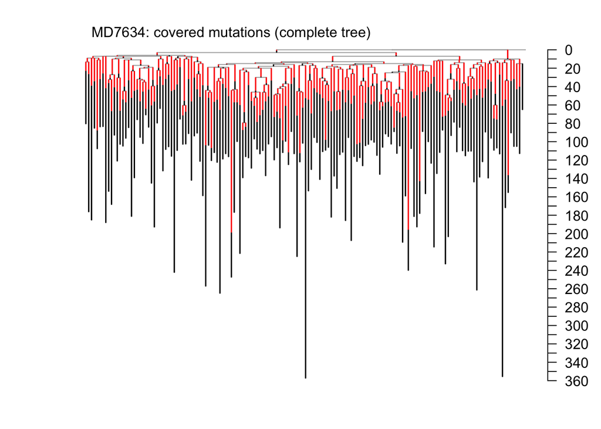

```
## scale= 10
```

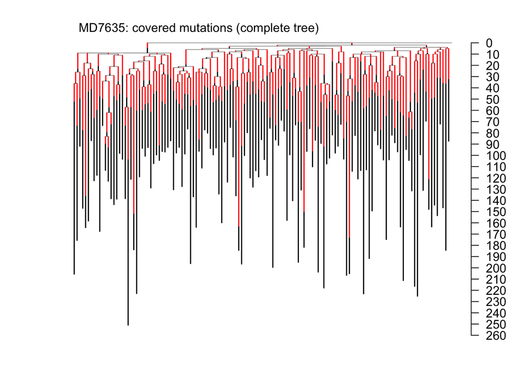

```
## scale= 10
```

```r
#----FINAL CHECK FOR WHICH MUTATIONS ARE COVERED (after resubmitting final designs)------------------------------

baitset_file=paste0(my_working_dir,"baitset_design/Sanger_Mouse_phylo_REDUCED_v2_TE-99621817_mm10/merged_probe_file_shareable_Sanger_Mouse_phylo_REDUCED_v2_TE-99621817_mm10_low.bed")
cat_bed=read.delim(baitset_file,header = F,col.names = c("Chr","Start","End","Probe_ID"))
cat_bed$Chr<-gsub("chr","",cat_bed$Chr)
covered_regions_GR<-GenomicRanges::makeGRangesFromDataFrame(cat_bed,seqnames.field = "Chr",start.field = "Start",end.field = "End")

all.muts<-lapply(all.muts,function(details) {
  details$covered_final=0

  #Intersect each details coordinates with the final covered regions
  details_GR<-GenomicRanges::makeGRangesFromDataFrame(details,seqnames.field = "Chrom",start.field="Pos",end.field = "Pos")
  overlaps<-GenomicRanges::findOverlaps(covered_regions_GR,details_GR)
  details$covered_final[overlaps@to] <- 1 #Record that each mutation at that coordinate is covered by the final baitset
  return(details)
})

#Write bed file of the covered indels and SNVs
dplyr::bind_rows(all.muts)%>%
  filter(covered_final==1 & Mut_type=="SNV")%>%
  dplyr::select(Chrom,Pos,Ref,Alt)%>%
  arrange(Chrom,Pos)%>%
  readr::write_delim(file="baitset_SNVs.bed",delim = "\t",col_names = F)

dplyr::bind_rows(all.muts)%>%
  filter(covered_final==1 & Mut_type=="INDEL")%>%
  dplyr::select(Chrom,Pos,Ref,Alt)%>%
  arrange(Chrom,Pos)%>%
  readr::write_delim(file="baitset_INDELs.bed",delim = "\t",col_names = F)

#Plot the complete trees
# Can see the mutations from the 15selected tips
temp=Map(details=all.muts,tree=all.trees,SampleID=names(all.trees),function(details,tree,SampleID){
  details$is.in.baitset <- details$covered_final == 1
  #tree=squash_tree(tree,cut_off=15)
  tree=plot_tree(tree, cex.label = 0,title = paste0(SampleID,": covered mutations (complete tree)"))
  add_annotation(tree=tree,
                 details=details,
                 list(),
                 annot_function=function(tree,details,matrices,node) {
                   add_binary_proportion(tree,details,matrices,node,bfield = "is.in.baitset",lwd = 1.5)
                 }
  )
})
```

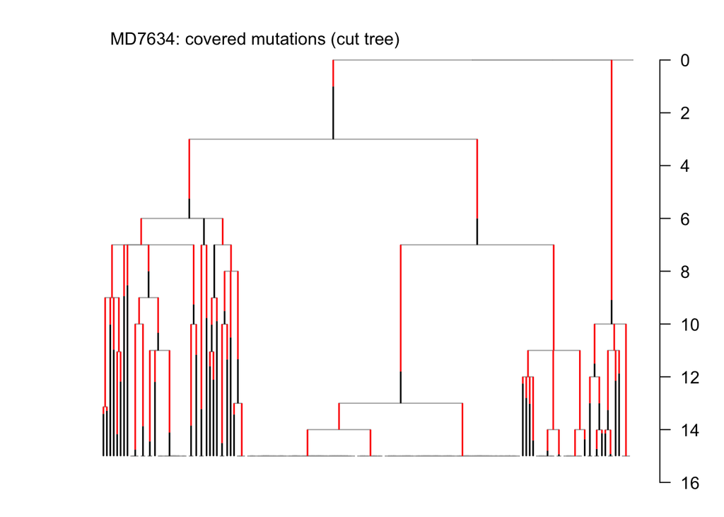

```
## scale= 2
```

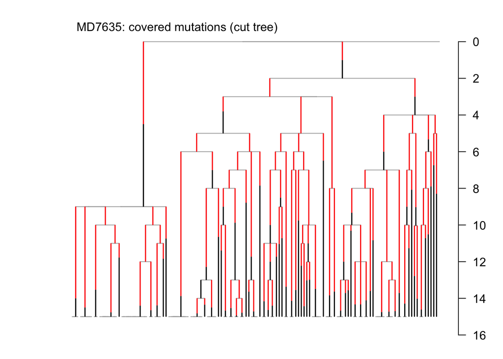

```
## scale= 2
```

```r
temp=Map(details=all.muts,tree=all.trees,SampleID=names(all.trees),function(details,tree,SampleID){
  details$is.in.baitset <- details$covered_final == 1
  tree=squash_tree(tree,cut_off=15)
  tree=plot_tree(tree, cex.label = 0,title = paste0(SampleID,": covered mutations (cut tree)"))
  add_annotation(tree=tree,
                 details=details,
                 list(),
                 annot_function=function(tree,details,matrices,node) {
                   add_binary_proportion(tree,details,matrices,node,bfield = "is.in.baitset",lwd = 1.5)
                 }
  )
})
```